# Lista 1 - Estatística Não-Paramétrica - 1/2015 - 30/03/2015

Augusto Cesar Ribeiro Nunes - 13/0103004

23 de março de 2015

# Questão 15

*Use the data in Table 5.8 to create a kernel density estimate for each group of subjects. Do the estimated densities appear to represent the same underlying distribution?*

Carregamento e descrição dos dados sobre os sujeitos dos Tipos A e B

```r
typeA <- c(3.6,2.6,4.7,8.0,3.1,8.8,4.6,5.8,4.0,4.6)
typeB <- c(16.2,17.4,8.5,15.6,5.4,9.8,14.9,16.6,15.9,5.3,10.5)
summary(typeA)
```

```
##    Min. 1st Qu.  Median    Mean 3rd Qu.    Max.
##   2.600   3.700   4.600   4.980   5.525   8.800
```

```r
summary(typeB)
```

```
##    Min. 1st Qu.  Median    Mean 3rd Qu.    Max.
##    5.30    9.15   14.90   12.37   16.05   17.40
```

Gráfico das duas densidades

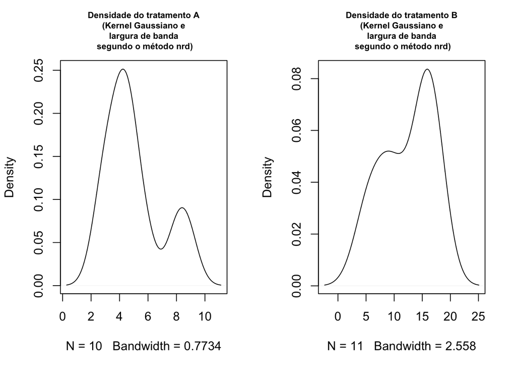

```r
par(mfrow=c(1,2), cex.main=0.7)
plot(density(typeA), main="Densidade do tratamento A\n (Kernel Gaussiano e \nlargura de banda\n segundo o método nrd)")
plot(density(typeB), main="Densidade do tratamento B\n (Kernel Gaussiano e \nlargura de banda\n segundo o método nrd)")
```

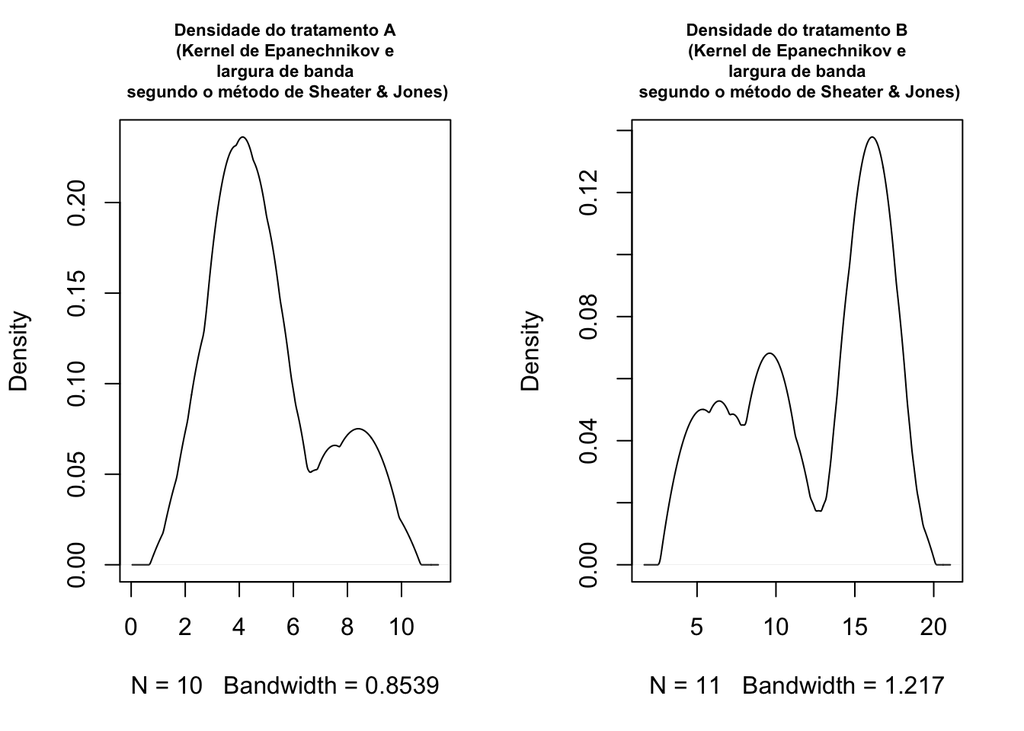

```r
plot(density(typeA, kernel="epanechnikov", bw="SJ"), main="Densidade do tratamento A\n (Kernel de Epanechnikov e \nlargura de banda\n segundo o método de Sheater & Jones)")
plot(density(typeB, kernel="epanechnikov", bw="SJ"), main="Densidade do tratamento B\n (Kernel de Epanechnikov e \nlargura de banda\n segundo o método de Sheater & Jones)")
```

Claramente, as densidades estimadas não representam a mesma população, já que:

# Questão 17

*Show that the asymptotic MISE is minimized when*

$h = \left(\frac{ \int k^2}{n \sigma_k^4 \int (f'')^2}\right)^\frac{1}{5}$

De fato, devemos mostrar que $\frac{\partial MISE(f, \hat{f})}{\partial h} = 0$ e que $\frac{\partial^2 MISE(f, \hat{f})}{\partial h^2} > 0$. Temos

$\frac{\partial MISE(f, \hat{f})}{\partial h} \simeq \frac{-1 \int k^2 h^{-2}}{n} + \sigma_k^4 h^3 \int (f'')^2$

O sinal $\simeq$ justifica-se pois usamos uma aproximação por séries de Taylor de ordem 1 para a expressão $MISE = \int \left(\frac{1}{nh} f(x) \int k^2(y) dy - \left[\frac{(f'')^2 h^4}{4} \sigma_k^4 \right] dx\right)$

Resolvendo a expressão acima para h, chegamos a

$h^5 \simeq \left(\frac{ \int k^2}{n \sigma_k^4 \int (f'')^2}\right)$

Para mostrar a segunda parte da questão, note que todas as quantidades envolvidas são $\geq 0$, isto é:

- $\int K > 0 \Rightarrow \int K^2 > 0$, por definição da função Kernel;
- $n, \sigma_k^4$ e $h^3$ também são positivos, por definição.

Então $\frac{\partial^2 MISE(f, \hat{f})}{\partial h^2} > 0$. Logo, $h^5 \simeq \left(\frac{ \int k^2}{n \sigma_k^4 \int (f'')^2}\right)$ é o mínimo da Média do Erro Quadrático Integrado.$\square$

# Questão 18

*If f is the density for a normal random variable with mean 0 and variance $\sigma^2$, show* $\int(f'')^2 = \frac{3}{8 \sqrt[2]{\pi} \sigma^5}$

De fato, temos $f(x) = \frac{1}{\sqrt{2\pi}\sigma^2} e^{\frac{-x^2}{2 \sigma^2}}$

E então

$f'' = -1/2\,{\frac { \sqrt{2}}{{\sigma}^{2} \sqrt{{\sigma}^{2}}}{{\rm e}^{-1/2\,{\frac {{x}^{2}}{{\sigma}^{2}}}}}}+1/2\,{\frac {{x}^{2} \sqrt{2}}{{\sigma}^{4} \sqrt{{\sigma}^{2}}}{{\rm e}^{-1/2\,{\frac {{x}^{2}}{{\sigma}^{2}}}}}}$

Que é diferente do resultado esperado.

# Questão 19

_Using the normal kernel K with $\sigma_k = 1$ and assuming the underlying data come from a normal population with mean 0 and variance $\sigma^2$, show the optimal bandwidth is $h = \left(\frac{4}{3}\right)^{\frac{1}{5}}\sigma n^{\frac{-1}{5}}$

**NÃO FIZ**